# Exercise Quality Prediction

Juan Carlos Moreno Reina

August 27, 2017

## Executive Summary

The goal of this project is to predict the manner in which a group of people did an exercise, based on the measurements collected from accelerometers on the belt, forearm, arm, and dumbbell of 6 participants. These participants were asked to perform barbell lifts correctly and incorrectly in 5 different ways.

A prediction model will be built using the training data and the goodness of this model will be assessed. Finally, this prediction model will be used to predict 20 different test cases.

## Exploratory data analysis

```r
library(ggplot2)
training_dat <- read.csv("./pml-training.csv",header=TRUE,na.strings = c("","NA","#DIV/0!"))
testing_dat <- read.csv("./pml-testing.csv",header=TRUE,na.strings = c("","NA","#DIV/0!"))
dim(training_dat);dim(testing_dat)
```

```
## [1] 19622   160
```

```
## [1]  20 160
```

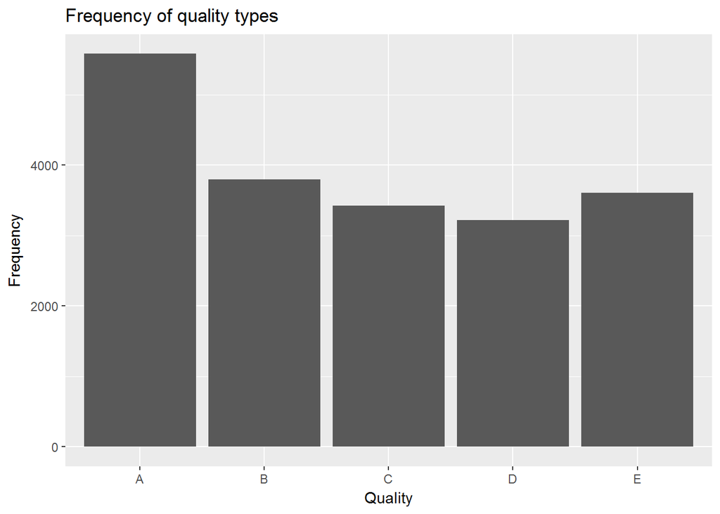

```r
qplot(training_dat$classe, main="Frequency of quality types",
      xlab="Quality", ylab="Frequency")
```

It can be observed that we have a huge training set, with 19622 records and 160 variables, where the most frequent quality classification is A. Moreover, there are many variables with NA values since some of them are statistics calculated/registered with less frequency. Therefore, I will consider only the variables that are raw measurements in the different axis from the 4 wearable devices.

```r
orig_training <- training_dat[,c(grep("^accel_.*",names(training_dat), value=T),
                                 grep("^gyros_.*",names(training_dat), value=T),
                                 grep("^magnet_.*",names(training_dat), value=T),
                                 grep("^roll_.*",names(training_dat), value=T),
                                 grep("^pitch_.*",names(training_dat), value=T),
                                 grep("^yaw_.*",names(training_dat), value=T),
                                 "classe")]
orig_testing <- testing_dat[,c(grep("^accel_.*",names(training_dat), value=T),
                                 grep("^gyros_.*",names(training_dat), value=T),
                                 grep("^magnet_.*",names(training_dat), value=T),
                                 grep("^roll_.*",names(training_dat), value=T),
                                 grep("^pitch_.*",names(training_dat), value=T),
                                 grep("^yaw_.*",names(training_dat), value=T))]
data.frame("Any NA in training"=anyNA(orig_training),"Any NA in testing"=anyNA(orig_testing))
```

```
##   Any.NA.in.training Any.NA.in.testing
## 1              FALSE             FALSE
```

Now, we can see that the NA values have been removed from both, the training and the testing data set.

## Fitting prediction models

First of all, I will configure the parallel processing for a better performance

```r
library(parallel)
library(doParallel)
cluster <- makeCluster(detectCores() - 1) # convention to leave 1 core for OS
registerDoParallel(cluster)
```

Then, I will configure trainControl object, so that the number of folds for the k-fold cross validation is set to 5, instead of 25 (default value), increasing the bias but decreasing the variance and gaining in performance again.

```r
library(caret)
fitControl <- trainControl(method = "cv",
                           number = 5,
                           allowParallel = TRUE)
```

Before fitting my prediction model, I will split my data set into the training and the testing set, as usual:

```r
set.seed(33833)
inTrain <- createDataPartition(y=orig_training$classe,p=0.75, list=FALSE)
training <- orig_training[inTrain,]
testing <- orig_training[-inTrain,]
```

Since there are still too many covariates and, most likely, many of them are very correlated and aren’t useful for my model, I will use the Principal Components Analysis to reduce the number of covariates.

In a first attempt, I set the threshold to 0.9 in the preProcess function, so that the function returned the number of Principal Components needed to capture the 90% of the variance. However, since I got a very poor accuracy, I increased the threshold to 0.99, what reduced the number of covariates from 48 to 35 Principal Components.

```r
preProc <- preProcess(training[,-49],method="pca",thresh=0.99,na.remove = TRUE)
trainPC <- predict(preProc,training[,-49])
trainPC$classe <- training$classe
testPC <- predict(preProc,testing[,-49])
```

Finally, I will develop the training model. Actually, I will fit three different models, with three different techniques (Random forest, Boosting and combining predictors). Then, I will pick the model with the highest accuracy. It is worth mentioning here that the methods “rf” and “gbm” will carry out the Cross Validation procedure using the K-fold technique with number of folds equals to five (k=5), as I previously configured.

```r
modelFit_rf <- train(classe ~ .,method="rf",data=trainPC,trControl = fitControl)
modelFit_gbm <- train(classe ~ .,method="gbm",data=trainPC,trControl = fitControl,verbose=F)
```

```r
predict_rf <- predict(modelFit_rf,testPC)
predict_gbm <- predict(modelFit_gbm,testPC)
combinedTestData <- data.frame(rf.pred=predict_rf, gbm.pred = predict_gbm, classe=testing$classe)
```

```r
modelFit_combined <- train(classe~ .,data=combinedTestData,method="rf",prox=TRUE,trControl = fitControl)
```

```r
predict_combined <- predict(modelFit_combined,combinedTestData)
confMatrix_rf<-confusionMatrix(testing$classe,predict_rf)
confMatrix_gbm<-confusionMatrix(testing$classe,predict_gbm)
confMatrix_combined<-confusionMatrix(testing$classe,predict_combined)
data.frame(Accuracy_rf=confMatrix_rf$overall[1],Accuracy_gbm=confMatrix_gbm$overall[1],
           Accuracy_combined=confMatrix_combined$overall[1])
```

[output not shown]

```r
confMatrix_rf
```

```
## Confusion Matrix and Statistics
##
##           Reference
## Prediction    A    B    C    D    E
##          A 1390    3    1    1    0
##          B   11  932    6    0    0
##          C    0   11  834   10    0
##          D    0    0   25  777    2
##          E    0    1    7    3  890
##
## Overall Statistics
##
##                Accuracy : 0.9835
##                  95% CI : (0.9795, 0.9869)
##     No Information Rate : 0.2857
##     P-Value [Acc > NIR] : < 2.2e-16
##
##                   Kappa : 0.9791
##  Mcnemar's Test P-Value : NA
##
## Statistics by Class:
##
##                      Class: A Class: B Class: C Class: D Class: E
## Sensitivity            0.9921   0.9842   0.9553   0.9823   0.9978
## Specificity            0.9986   0.9957   0.9948   0.9934   0.9973
## Pos Pred Value         0.9964   0.9821   0.9754   0.9664   0.9878
## Neg Pred Value         0.9969   0.9962   0.9904   0.9966   0.9995
## Prevalence             0.2857   0.1931   0.1780   0.1613   0.1819
## Detection Rate         0.2834   0.1900   0.1701   0.1584   0.1815
## Detection Prevalence   0.2845   0.1935   0.1743   0.1639   0.1837
## Balanced Accuracy      0.9954   0.9899   0.9751   0.9879   0.9975
```

Finally, I will predict the quality in the original testing data set, that I loaded from the csv file “pml-testing.csv”.

```r
origtestPC <- predict(preProc,orig_testing)
orig_predict_rf <- predict(modelFit_rf,origtestPC)
orig_predict_rf
```

```
##  [1] B A B A A E D B A A B C B A E E A B B B
## Levels: A B C D E
```

De-register parallel processing cluster

```r
stopCluster(cluster)
registerDoSEQ()
```